# Bayes_1_Specificazione della_distribuzione_a_priori

NikolayNikolaev

2023-05-26

# Bayes_1_Specificazione della_distribuzione_a_priori

Si intende stimare la proporzione di soggetti che soffrono di sintomi gravi dovuti al COVID-19 e non sono vaccinati nella popolazione italiana.

• In base alle attuali conoscenze a priori si assume 0.3 come valore plausibile per la mediana della distribuzione e 0.5 come valore plausibile per il 90-esimo percentile della distribuzione a priori. • Si utilizza la funzione beta.select della libreria LearnBayes per determinare i parametri $\alpha_1$ e $\beta_1$ della distribuzione a priori con la funzione seguente `learnBayes::beta.select`. Le misure di posizione devono essere definite come una lista specificando la mediana quantile1 ed il novantesino centile quantile2 della distribuzione

```r
quantile1 <- list(p = 0.5, x=0.3)
quantile1
```

```
## $p
## [1] 0.5
##
## $x
## [1] 0.3
```

```r
quantile2 <- list(p = 0.9, x=0.5)
quantile2
```

```
## $p
## [1] 0.9
##
## $x
## [1] 0.5
```

La funzione beta.select restituisce i valori dei due parametri della distribuzione Beta che rispettano i vincoli imposti

```r
require(LearnBayes)
beta.select(quantile1, quantile2)
```

```
## [1] 3.26 7.19
```

da cui risulta la distribuzione a priori $p(\theta)$ ~ $Beta(3.26, 7.19)$ e la proporzione media di ipertesi nella popolazione in base alle conoscenza a priori e’:

```r
M <- 3.26/(3.26+7.19); M
```

```
## [1] 0.3119617
```

## 1. Determinazione della distribuzione a posteriori.

Supponendo di osservare adesso un campione casuale di persone ricoverate per covid-19 in un’ospedale della zone e di riscontrare che su 12 pazienti complessivi ($n_1$ ) pazienti 6 non risultano vaccinati. Nel seguito si utilizza $k_1 = 6$ - sucessi e $f_1 = (n_1- k_1)$ - insucessi

Si disegna - la distribuzione a priori: - verosimiglianza - la distribuzione a posteriori

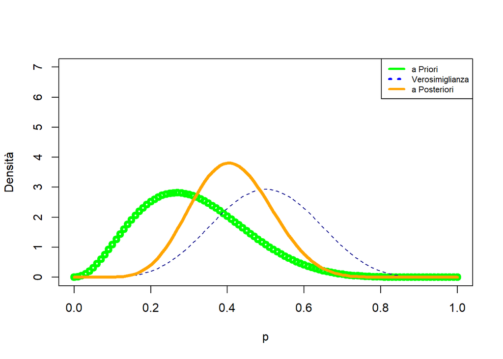

```r
alpha1 <- 3.26
beta1 <- 7.19
n1 <- 12
k1 <- 6
# a priori
pval <- seq(0,1, by = 0.01)
plot(pval, dbeta(pval,alpha1, beta1),
xlab="p",
ylab="Densità",
ylim=c(0,7),
lty=3,
lwd=4,
col="green")
# verosimiglianza
lines(pval,dbeta(pval, k1+1,n1-k1+1),
lty = 2,
lwd = 1, col = "darkblue")
# a posteriori
lines(pval, dbeta(pval,
k1 + alpha1,
n1-k1+beta1),
lty=1,lwd=4,
col="orange")

legend("topright",
c("a Priori","Verosimiglianza","a Posteriori"),
lty=c(1,3,1),
lwd=c(3,3,3),
col=c("green", "blue","orange" ),
cex = 0.7)
```

• Si nota che la distribuzione di riferimento per l’inferenza ovvero la distribuzione a posteriori è un compromesso tra la distribuzione iniziale che ha portato ad ipotizzare certi valori per il parametro (e che è abbastanza informativa) e la verosimiglianza basata sulle rilevazioni effettuate con il campione che è abbastanza diversa dalla prior. • La media della distribuzione a posteriori si trova tra la media della prior e quella della verosimiglianza. • La distribuzione a posteriori ha una variabilità ridotta rispetto alla variabilità della distribuzione iniziale.

## 2. Aggiornamento della distribuzione a posteriori

Supponendo di osservare un altro campione di pazienti ricoverati in un altro ospedale di Milano la distribuzione a posteriori viene aggiornata in base alle nuove evidenze empiriche. Su 27 pazienti ricoverati per covid-19, 19 risultano senza vaccino $n = 27+12 = 39, k = 19+6 = 25$.

Il confronto grafico tra la prima e la seconda distribuzione a posteriori ci permette di stabilire come si modifica l’inferenza sul parametro quando le evidenze dei dati sono maggiori

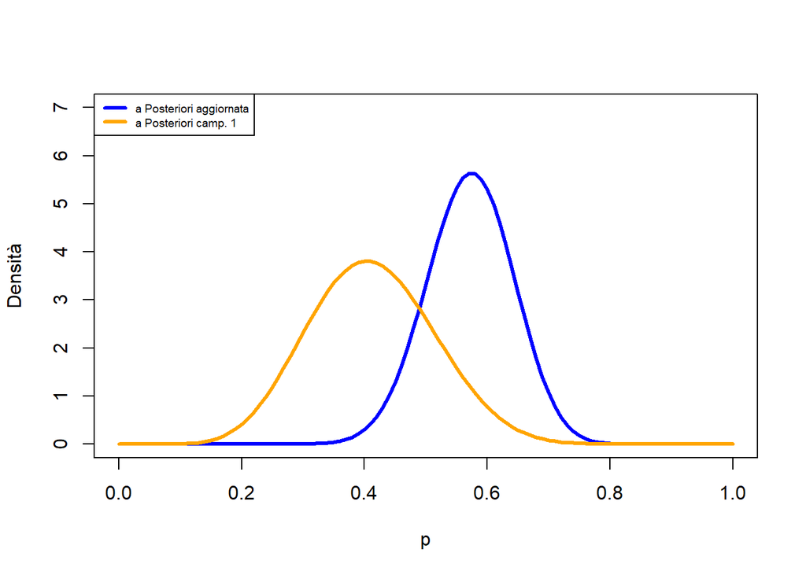

```r
k <- 19 +k1
n<- 39
# a posteriori aggiornata
plot(pval, dbeta(pval,
alpha1 + k,
beta1+n-k),
xlab="p",
type = "l",
ylab="Densità",
ylim=c(0,7),
lty=1,
lwd=3,
col="blue")
# a posteriori campione 1
lines(pval, dbeta(pval,
k1 + alpha1,
n1-k1+beta1),
lty=1,lwd=3,
col="orange",
add=TRUE)
legend("topleft",
c("a Posteriori aggiornata", "a Posteriori camp. 1"),
lty=c(1,1),
lwd=c(3,3),
col=c("blue", "orange" ),
cex = 0.6)
```

Il valore atteso della distribuzione a posteriori aggiornata con le ulteriori evidenze campionarie è

```r
(alpha1+k)/(n+alpha1 + beta1)
```

```
## [1] 0.5714863
```

Notiamo che la distribuzione a posteriori è proporzionale al prodotto della prior e della verosimiglianza.